# King County, House Price Prediction

##### 7.6 Water Front

```
##
##     0     1
## 21434   163
```

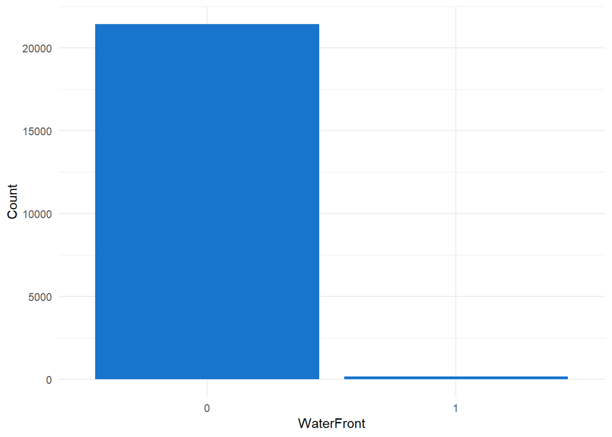

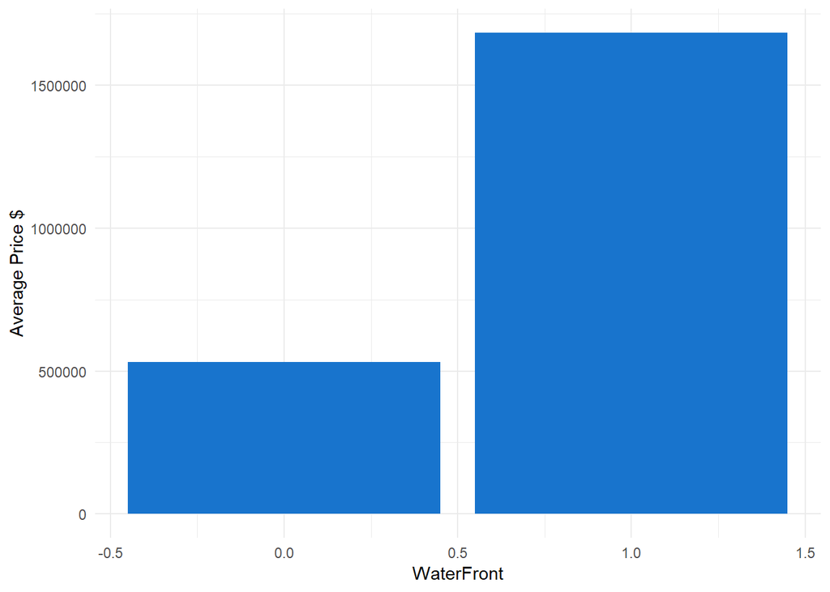

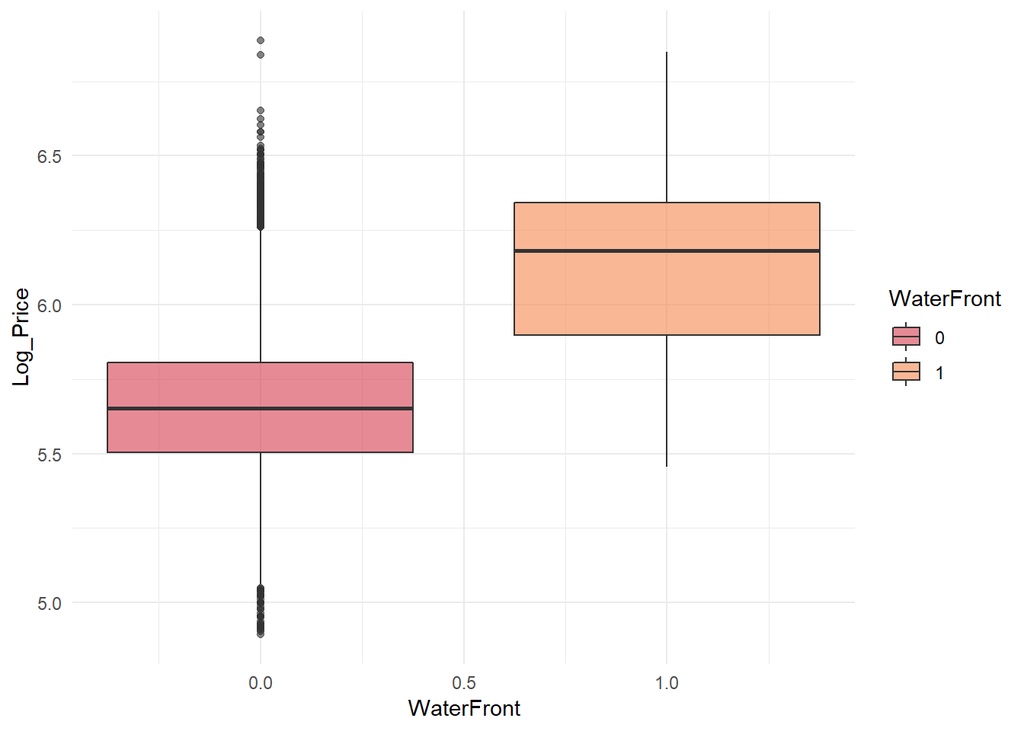

##### 7.7 Sqft_living

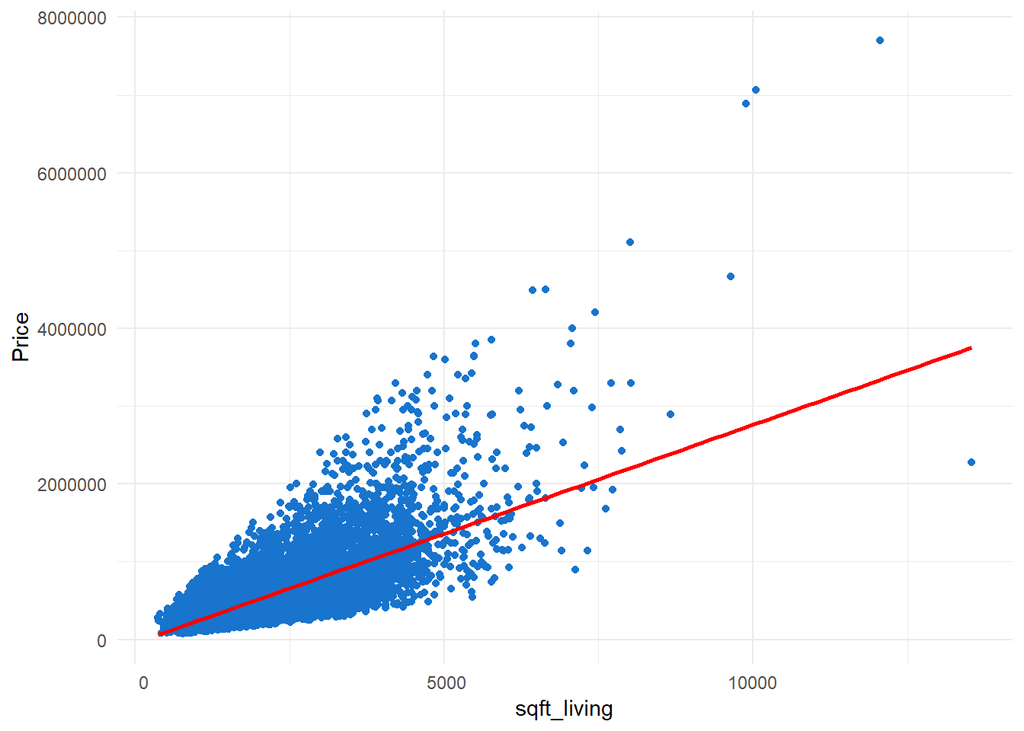

##### 7.8 Sqft_living15

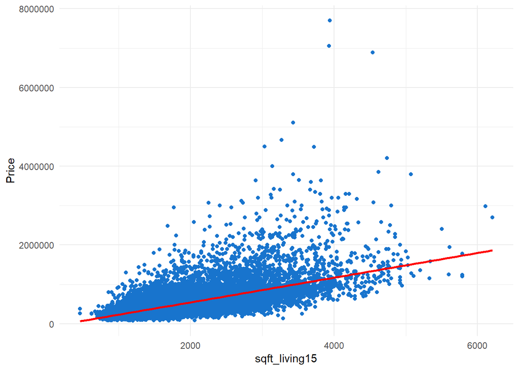

##### 7.9 Sqft_lot

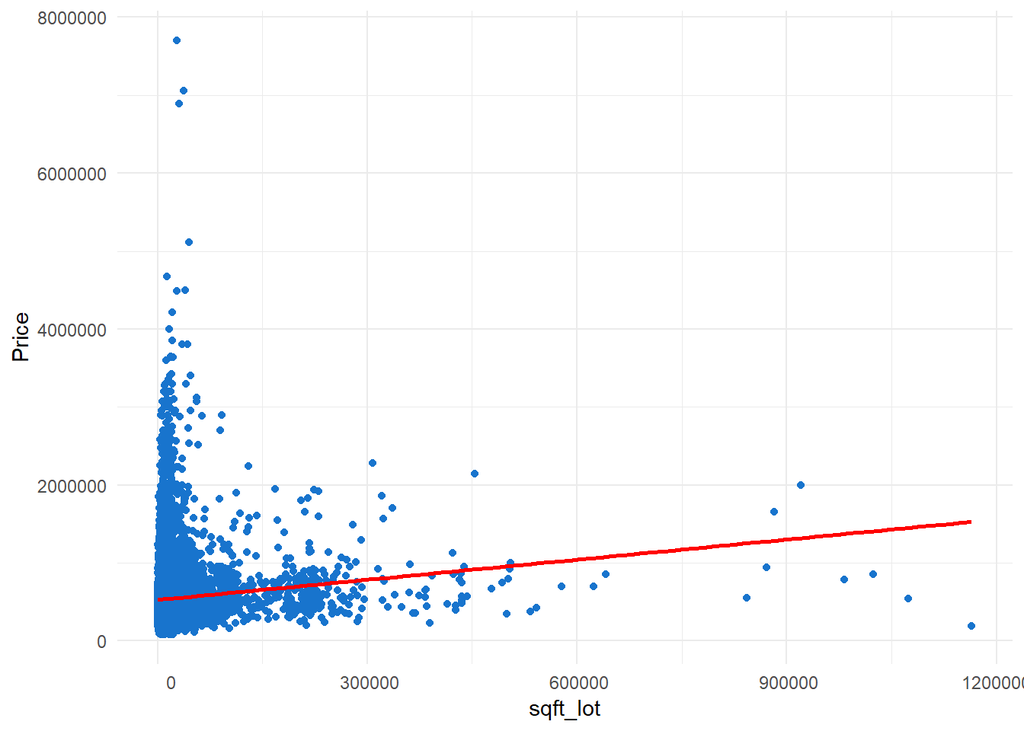

##### 7.10 Sqft_lot15

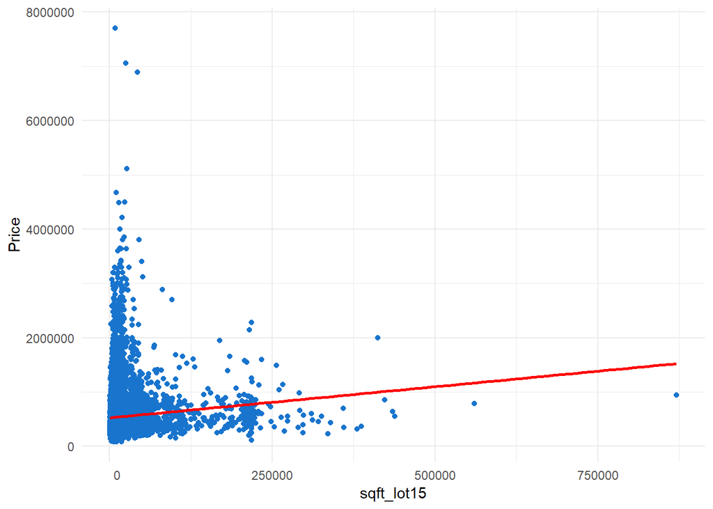

##### 7.11 Sqft_above

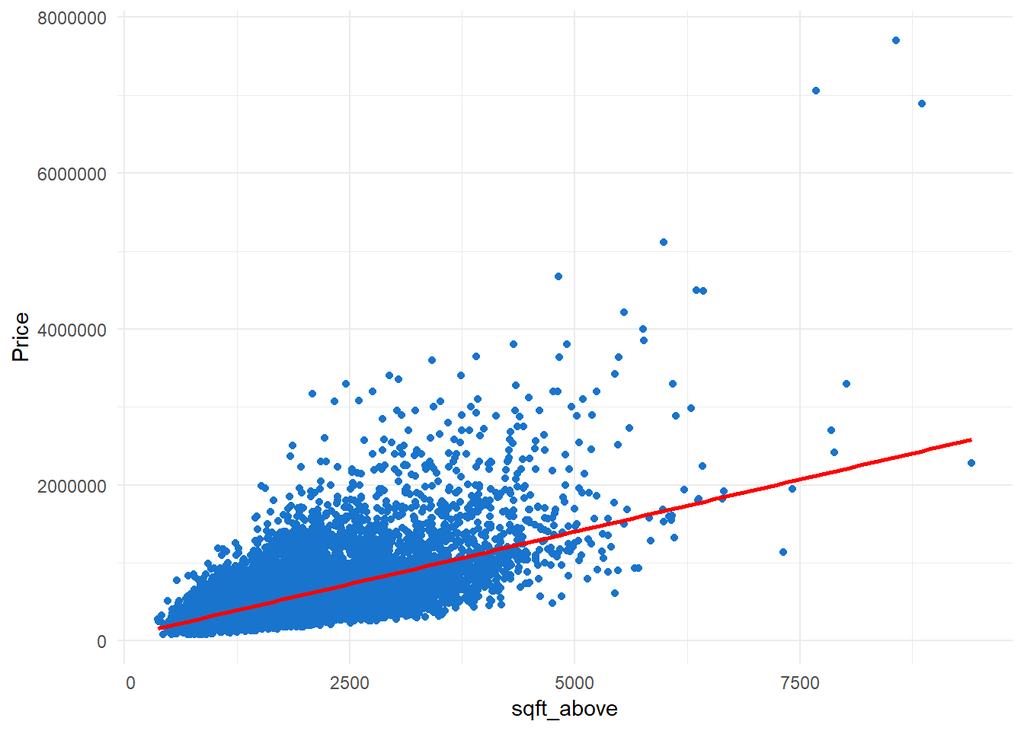

##### 7.12 Sqft_basement

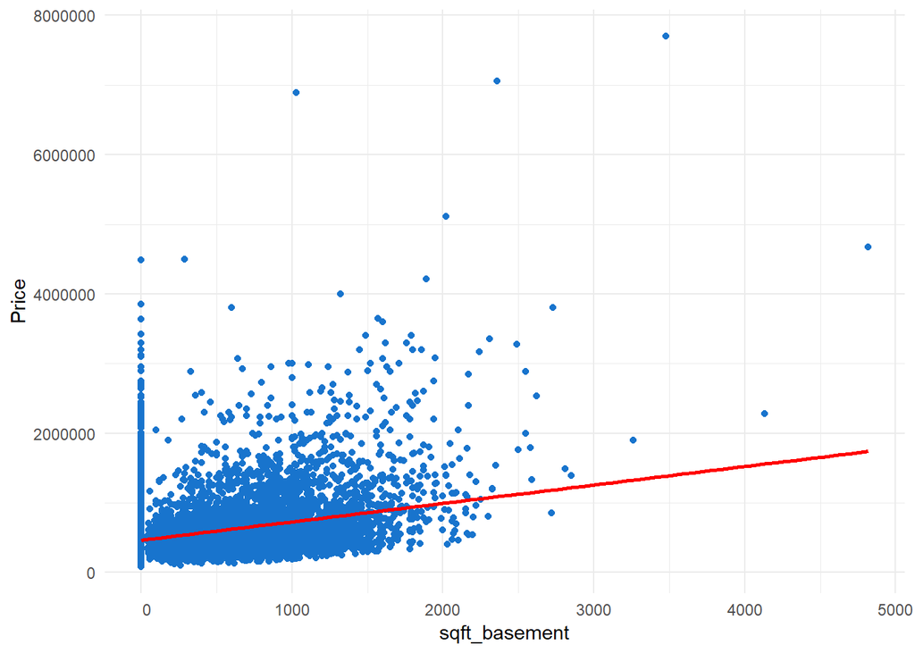

##### 7.13 Views

```
##
##     0     1     2     3     4
## 19475   332   961   510   319
```

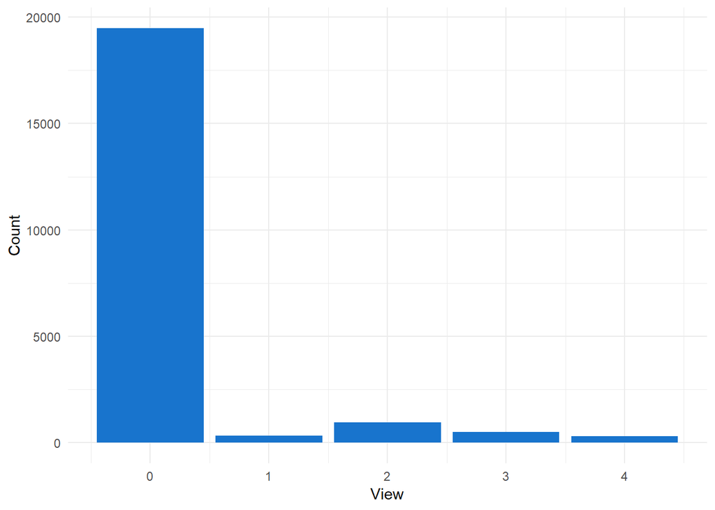

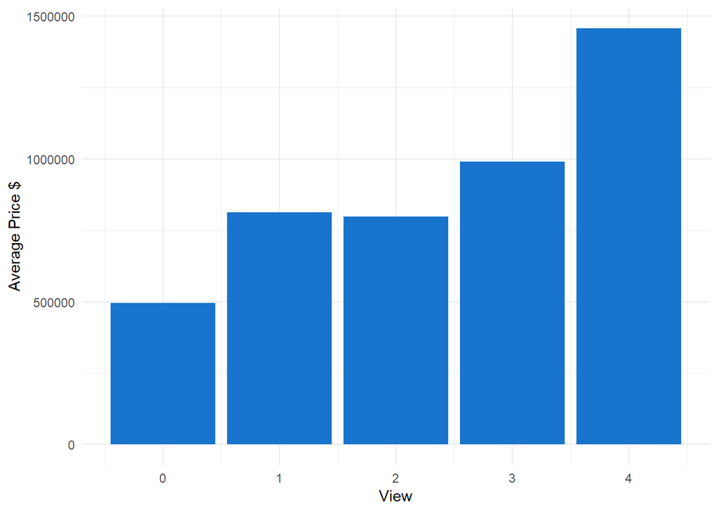

##### 7.14 Grade

```
##
##    3    4    5    6    7    8    9   10   11   12   13
##    1   27  242 2038 8974 6065 2615 1134  399   89   13
```

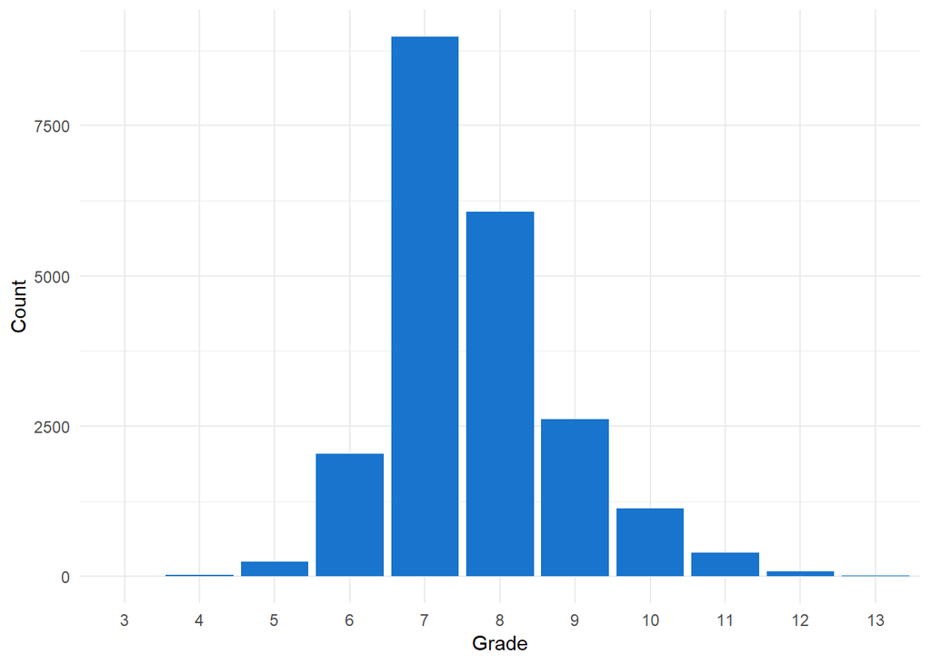

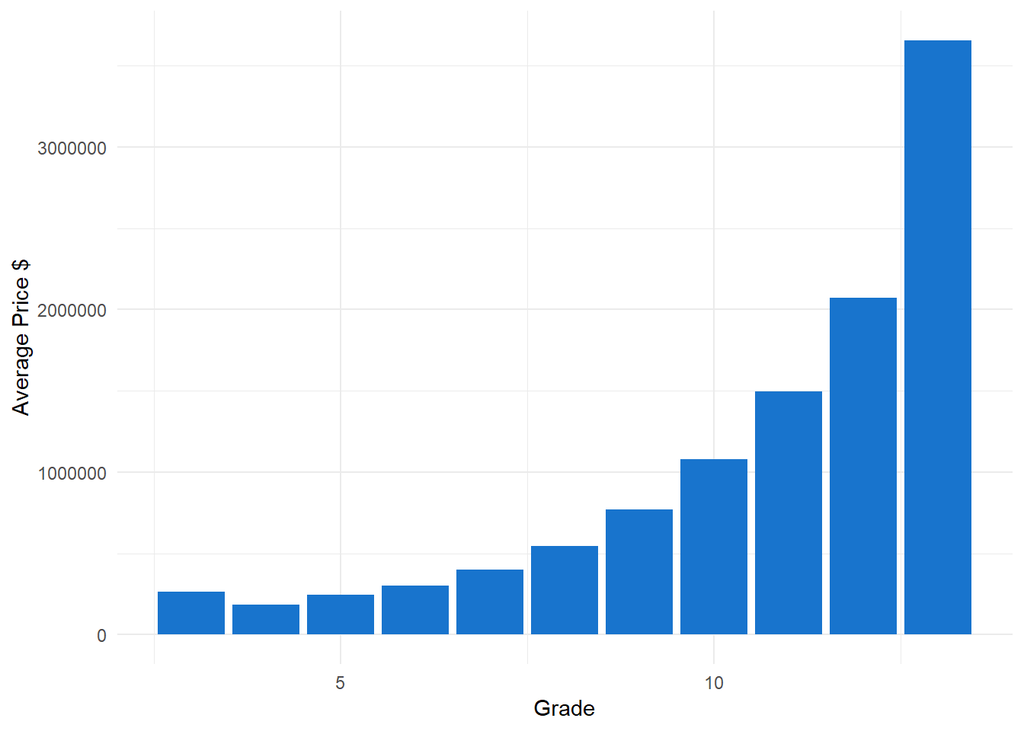

[figure not shown]

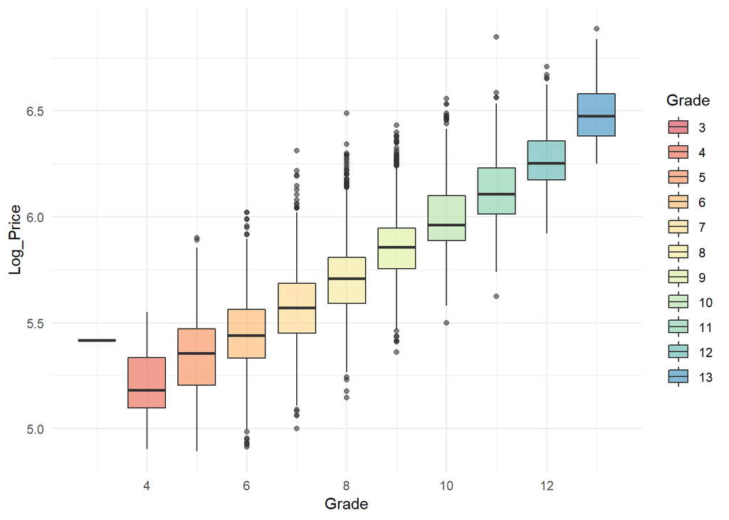

##### 7.15 Year Built

```
##
## 1900 1901 1902 1903 1904 1905 1906 1907 1908 1909 1910 1911 1912 1913 1914
##   87   29   27   46   45   74   92   65   86   94  134   73   79   58   54
## 1915 1916 1917 1918 1919 1920 1921 1922 1923 1924 1925 1926 1927 1928 1929
##   64   79   56  120   88   98   76   95   84  139  165  180  115  126  114
## 1930 1931 1932 1933 1934 1935 1936 1937 1938 1939 1940 1941 1942 1943 1944
##   90   61   38   30   21   24   40   68   52  106  156  161  223  170  140
## 1945 1946 1947 1948 1949 1950 1951 1952 1953 1954 1955 1956 1957 1958 1959
##   95  126  263  234  195  249  229  220  222  305  271  198  198  224  334
## 1960 1961 1962 1963 1964 1965 1966 1967 1968 1969 1970 1971 1972 1973 1974
##  248  224  312  255  172  187  249  350  381  280  132  104  149  149  162
## 1975 1976 1977 1978 1979 1980 1981 1982 1983 1984 1985 1986 1987 1988 1989
##  189  253  417  387  343  240  199  105  212  229  227  215  294  270  290
## 1990 1991 1992 1993 1994 1995 1996 1997 1998 1999 2000 2001 2002 2003 2004
##  317  224  198  202  249  169  194  177  239  263  218  305  222  420  433
## 2005 2006 2007 2008 2009 2010 2011 2012 2013 2014 2015
##  450  453  417  367  230  143  130  170  201  559   38
```

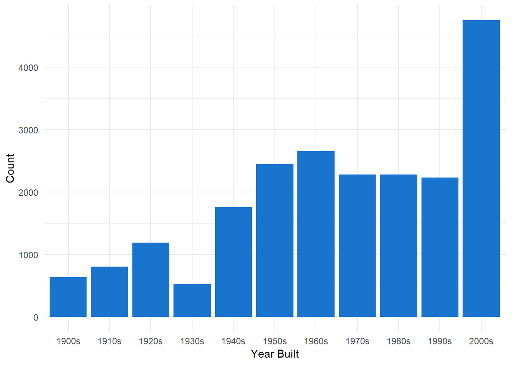

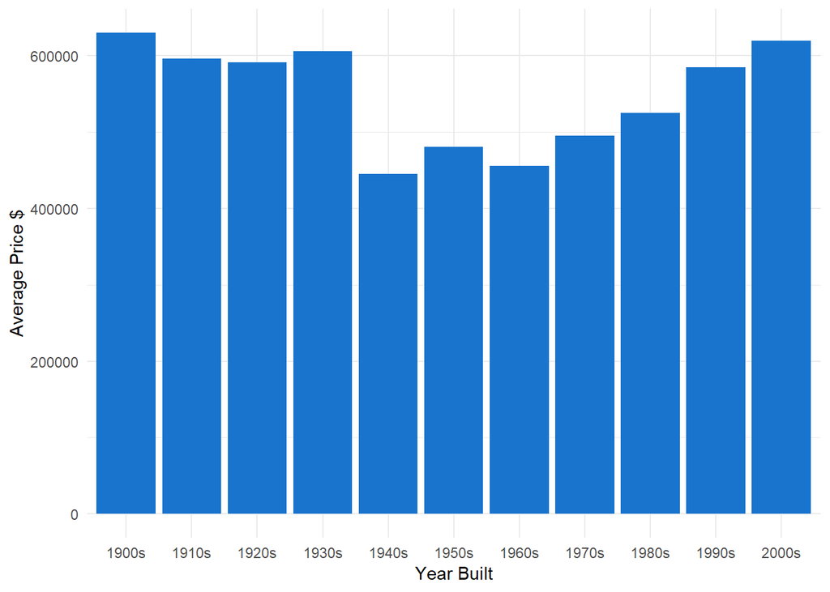

##### 7.16 Year Renovated

```
##
##     0  1934  1940  1944  1945  1946  1948  1950  1951  1953  1954  1955
## 20683     1     2     1     3     2     1     2     1     3     1     3
##  1956  1957  1958  1959  1960  1962  1963  1964  1965  1967  1968  1969
##     3     3     5     1     4     2     4     5     5     2     8     4
##  1970  1971  1972  1973  1974  1975  1976  1977  1978  1979  1980  1981
##     9     2     4     5     3     6     3     8     6    10    11     5
##  1982  1983  1984  1985  1986  1987  1988  1989  1990  1991  1992  1993
##    11    18    18    17    17    18    15    22    25    20    17    19
##  1994  1995  1996  1997  1998  1999  2000  2001  2002  2003  2004  2005
##    19    16    15    15    19    17    35    19    22    36    26    35
##  2006  2007  2008  2009  2010  2011  2012  2013  2014  2015
##    24    35    18    22    18    13    11    37    91    16
```

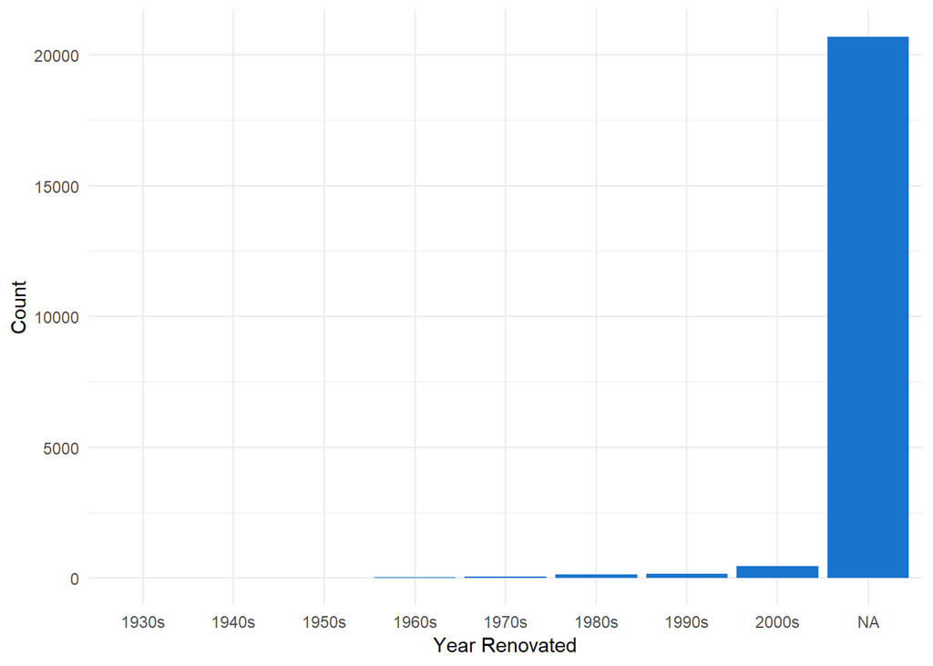

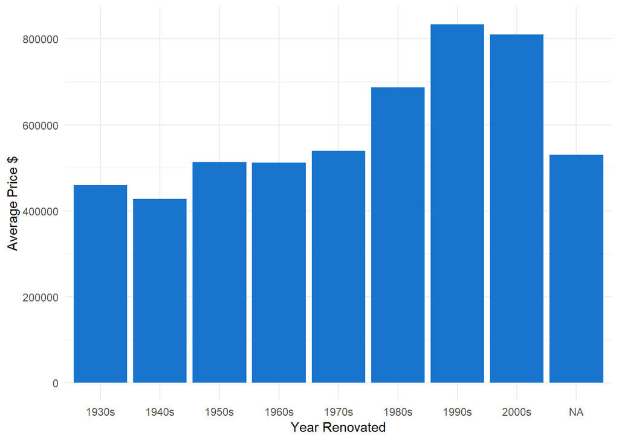

##### 7.17 House Price Binning

```
##      0%     25%     50%     75%    100%
##   78000  320000  450000  645500 7700000
```

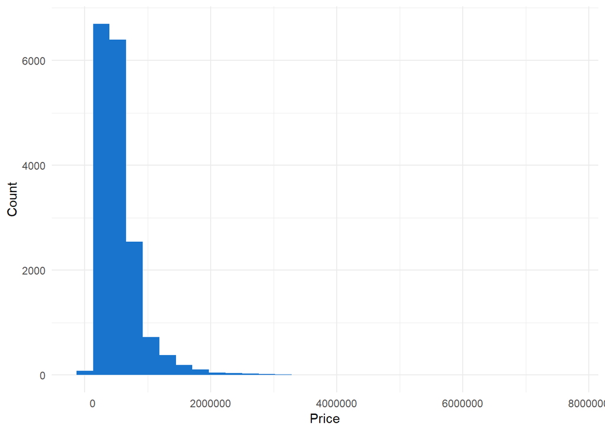

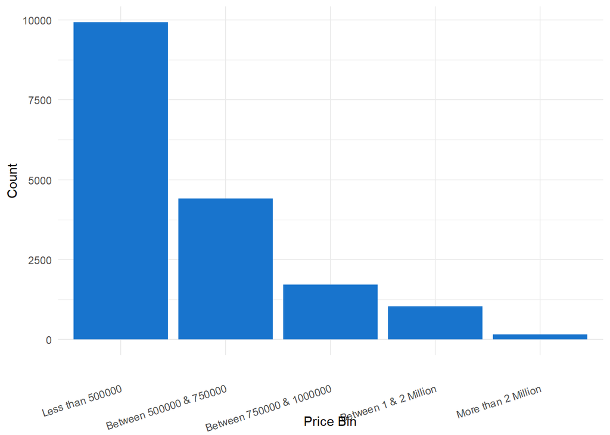

#### 8. Feature Engineering/Creation

In this section we will do some variable transformation and variable creation to improve our final results. Some variables will be created however will be eliminated later by our regularization model as we apply penalties using whether Lasso or Ridge regressions

```
##
##     0     1
## 21167   430
```

#### 9. Correlations

Correlations are used to identify which variable has more correlation with our target variable. We will explore correlations using a heat map for a better understanding of the data. Again, it is important to note that some categorical features correlations are calculated within the heat map due to their numeric nature. So we will not take them into consideration.

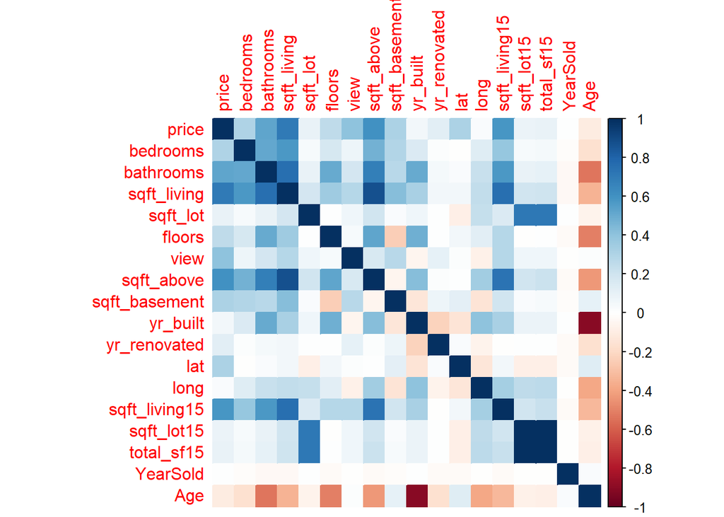

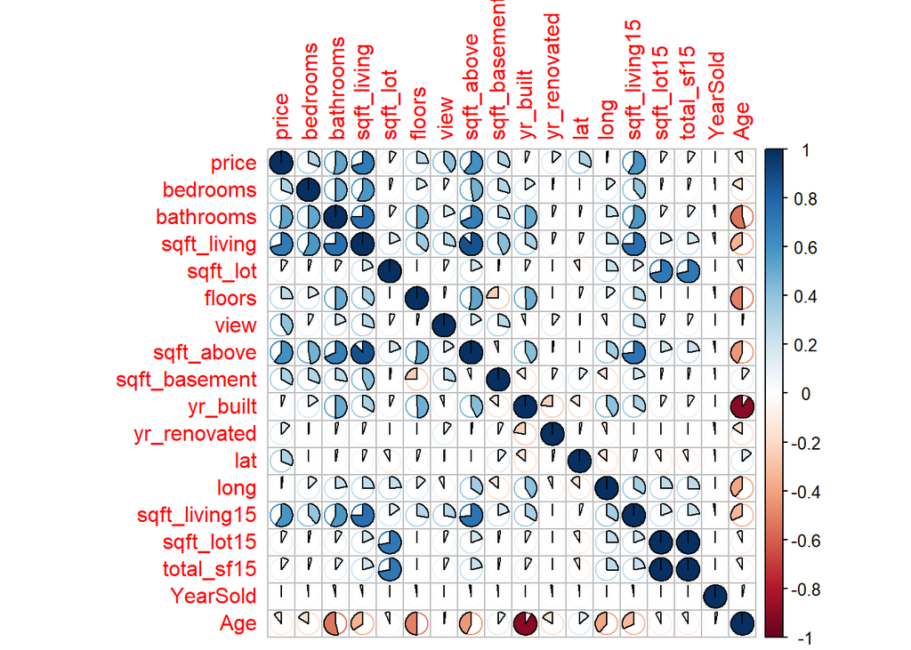

#### 10. Outliers

Outliers represent a big problem for numerical variables and can decrease the quality of any model and cause bias in our predeictions. We will look at numerical variables manually using ggplot and remove outliers accordingly. I tried to use a for loop to remove outliers however many values ended up being removed so I choose some features manually and removed outliers visually.

Train and test data will be splits for outlier removal then we will bind them again for further preprocessing. It is also important to note than not all columns with numeric values are classified as numeric variables. Some variables represent quality for example.

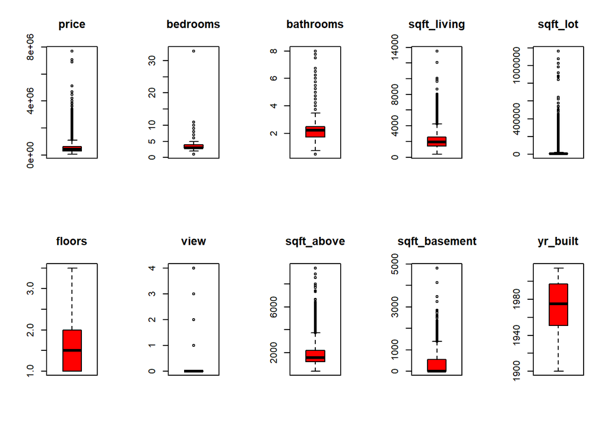

```
## [1] 17277
```

```
## [1] 17213
```

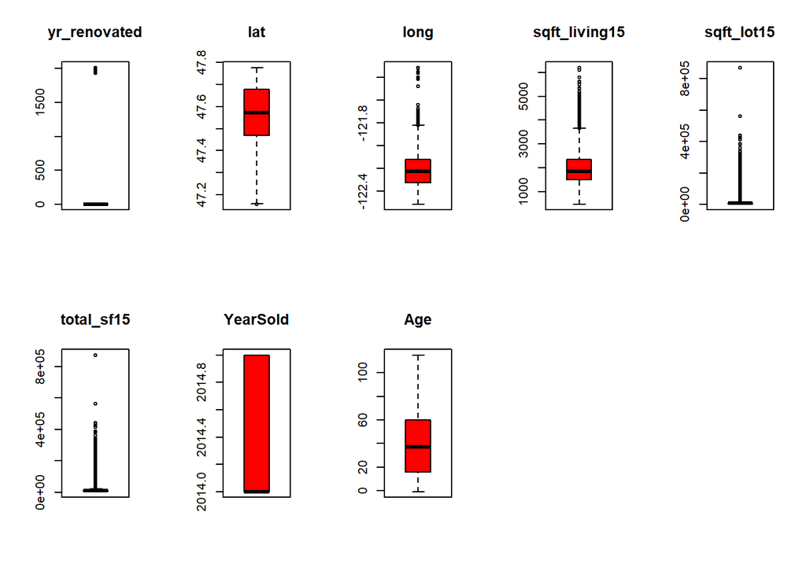

#### 11. Skewness

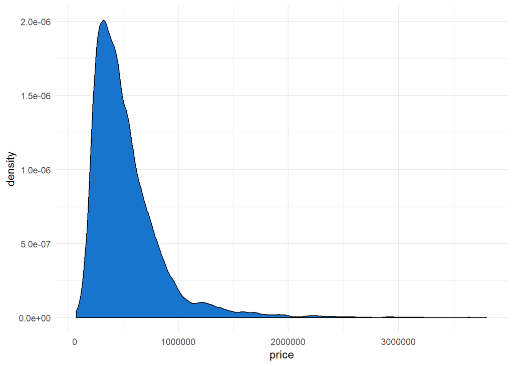

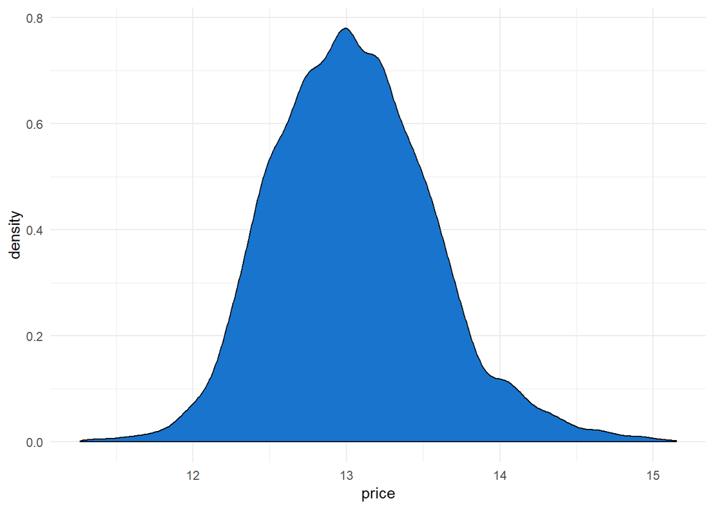

#### 12. Factorizing Features

There are some numerical features that should be perseved as categorical ones, in order to gasp correctly the information inside those columns. If we analyze some features we will see that we have categorical values encoded as numeric. We will transform some of those into factors since they cant be used in any calculation.

#### 13. Scaling

We will now standardize all the numeric features since the range of the data values varies widely. We will scale the variables so that their scale varies around zero. This is done so that the variance of the features are in the same range. If a feature’s variance in orders of magnitude more than the variance of other features, that particular feature might dominate other features in the dataset, which is not something we want happening in our model.

#### 14. More Feature Engineering

We will now create bins for both longitude and latitude since some models dont accept factors more than 53 categories. Therefore some of these bins will be used later in some models and for others we will normally use longitude and latitude.

```
## [1] 6.400703
```

```
## [1] -2.168944
```

```
## [1] 1.569822
```

```
## [1] -2.91653
```

#### 15. Data split

To facilitate the data cleaning and feature engineering we merged train and test datasets. We now split them again to create our final model.

```
## [1] 17213    25
```

```
## [1] 4320   25
```

#### 15.1 Train / Validation split

We are going to split the annotated dataset in training and validation for the later evaluation of our regression models

```
## [1] 14344    24
```

```
## [1] 2869   24
```

#### 16. Modeling

##### 16.1 Regression Metrics

First we will define three metric functions to measure the strength and accuracy of our model.

##### 16.2 Linear Regression

We will now start with a baseline linear model to evaluate our prediction and further we will use regularization methods to do feature elimination and optimize our results

###### 16.2.1 Evaluation

```
##
## Call:
## lm(formula = price ~ bedrooms + bathrooms + sqft_living + sqft_lot +
##     sqft_above + floors + waterfront + view + condition + grade +
##     sqft_basement + zipcode + sqft_living15 + sqft_lot15 + yr_built +
##     NewHouse + Age + long + lat + has_basement, data = training)
##
## Residuals:
##      Min       1Q   Median       3Q      Max
## -1.24701 -0.09664  0.00356  0.10066  1.02638
##
## Coefficients: (1 not defined because of singularities)
##                 Estimate Std. Error t value Pr(>|t|)
## (Intercept)    1.234e+01  2.182e-01  56.568  < 2e-16 ***
## bedrooms2      2.472e-02  1.671e-02   1.479 0.139054
## bedrooms3      4.528e-02  1.681e-02   2.694 0.007071 **
## bedrooms4      4.515e-02  1.724e-02   2.618 0.008849 **
## bedrooms5      2.353e-02  1.825e-02   1.289 0.197340
## bedrooms6     -2.607e-03  2.243e-02  -0.116 0.907476
## bedrooms7     -1.015e-01  4.112e-02  -2.470 0.013542 *
## bedrooms8     -6.740e-02  6.698e-02  -1.006 0.314304
## bathrooms0.75  2.985e-01  1.076e-01   2.775 0.005521 **
## bathrooms1     3.238e-01  1.045e-01   3.099 0.001947 **
## bathrooms1.25  3.384e-01  1.249e-01   2.710 0.006744 **
## bathrooms1.5   3.467e-01  1.047e-01   3.312 0.000930 ***
## bathrooms1.75  3.734e-01  1.046e-01   3.568 0.000361 ***
## bathrooms2     3.703e-01  1.047e-01   3.537 0.000406 ***
## bathrooms2.25  3.977e-01  1.048e-01   3.796 0.000148 ***
## bathrooms2.5   4.056e-01  1.047e-01   3.873 0.000108 ***
## bathrooms2.75  4.034e-01  1.049e-01   3.846 0.000121 ***
## bathrooms3     3.945e-01  1.050e-01   3.756 0.000173 ***
## bathrooms3.25  4.175e-01  1.052e-01   3.969 7.26e-05 ***
## bathrooms3.5   4.134e-01  1.052e-01   3.931 8.50e-05 ***
## bathrooms3.75  4.073e-01  1.067e-01   3.818 0.000135 ***
## bathrooms4     3.864e-01  1.067e-01   3.622 0.000294 ***
## bathrooms4.25  4.212e-01  1.084e-01   3.887 0.000102 ***
## bathrooms4.5   3.988e-01  1.078e-01   3.701 0.000216 ***
## bathrooms4.75  4.008e-01  1.159e-01   3.457 0.000549 ***
## bathrooms5     3.942e-01  1.177e-01   3.350 0.000809 ***
## bathrooms5.25  4.184e-01  1.399e-01   2.990 0.002793 **
```

[output cut: 213 more lines]

```
## yr_built2012  -1.147e-01  3.323e-02  -3.452 0.000558 ***
## yr_built2013  -9.139e-02  3.218e-02  -2.840 0.004518 **
## yr_built2014  -7.987e-02  3.280e-02  -2.435 0.014899 *
## yr_built2015  -1.451e-01  4.717e-02  -3.077 0.002096 **
## NewHouse1     -2.755e-02  1.968e-02  -1.400 0.161589
## Age           -2.637e-02  3.940e-03  -6.693 2.27e-11 ***
## long          -4.750e-02  8.548e-03  -5.557 2.80e-08 ***
## lat            7.363e-02  1.213e-02   6.072 1.29e-09 ***
## has_basement1  3.050e-02  6.156e-03   4.955 7.31e-07 ***
## ---
## Signif. codes:  0 '***' 0.001 '**' 0.01 '*' 0.05 '.' 0.1 ' ' 1
##
## Residual standard error: 0.1791 on 14096 degrees of freedom
## Multiple R-squared:  0.8847, Adjusted R-squared:  0.8826
## F-statistic: 437.7 on 247 and 14096 DF,  p-value: < 2.2e-16
```

```
## [1] 2.961766e-18
```

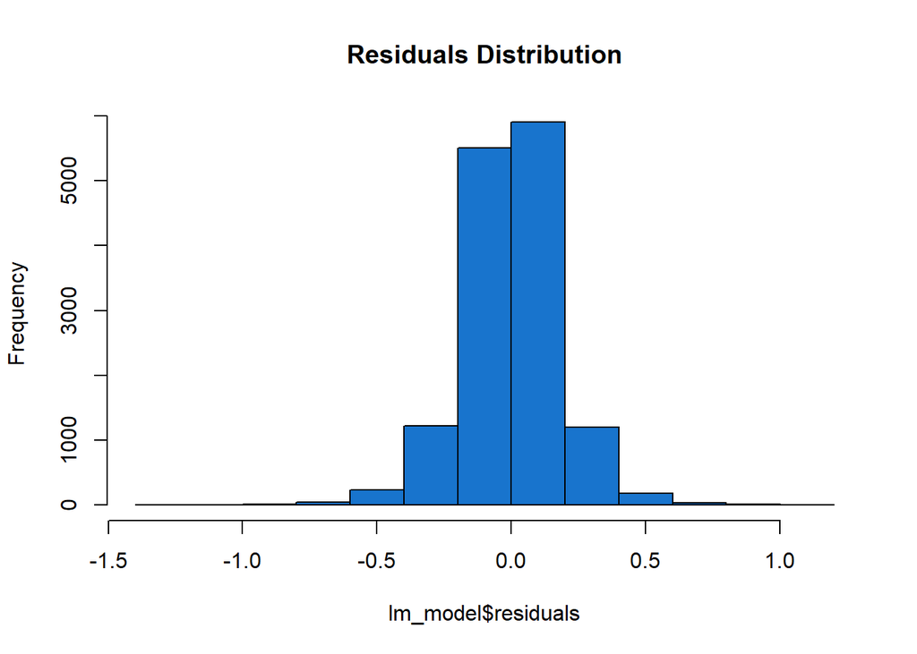

```
## [1] "The mean absolute error for linear regression is  0.128446464125415 and mape is 0.00986654288017976 and rmse is  0.17442244527498"
```

```
## [1] "The mean absolute error for linear regression is  70573.3334715268 and mape is 0.130475009905006 and rmse is  127997.618902608"
```

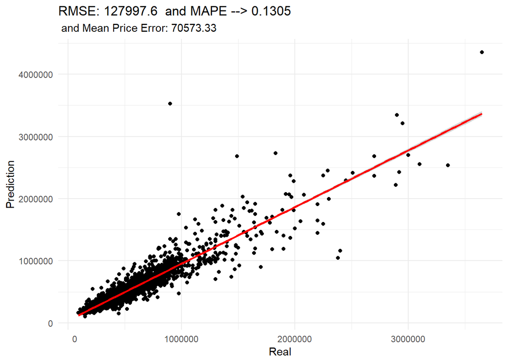

```
## [1] "R-Squared: 0.884665123187455"
```

Now that we have an intial regression model, we can start working to improve our prediction by practicing regularization. Regularization methods add a penalty on the variables and lead the model into having fewer coefficients. These methods are Lasso and Ridge regressions.

Ridge and Lasso Regressions are similar in terms of methodology, the superficial difference between both models is that Ridge squares the variables while Lasso regression uses the absolute value.Though, Lasso is better than ridge regression at reducing the variance in models that contain a lot of useless variables, so in the context of our dataset, Lasso will be very beneficial in improving predictions.

In summary, using Ridge regression and Lasso regression both helps with variable elimination however Lasso is mainly useful for excluding useless variables from our regression equation which makes the final prediction equation simpler. On the other hand Ridge will be useful when most of our features are good for the prediction.

##### 16.3 Ridge Regression

The alpha parameter represents the penalty in the regularization process. For Ridge regression, alpha value of 0 is used while in Lasso we use an alpha value of 1.

###### 16.3.1 Ridge Evaluation

Plotting the RMSE for the different lambda values, we can see the impact of this parameter in the model performance. Small values seem to work better for this dataset. Plotting the coefficients for different lambda values. As expected the larger the lambda (lower Norm) value the smaller the coefficients of the features. However, as we can see at the top of the features, there is no feature selection.

```
##             Length Class      Mode
## a0            100  -none-     numeric
## beta        26500  dgCMatrix  S4
## df            100  -none-     numeric
## dim             2  -none-     numeric
## lambda        100  -none-     numeric
## dev.ratio     100  -none-     numeric
## nulldev         1  -none-     numeric
## npasses         1  -none-     numeric
## jerr            1  -none-     numeric
## offset          1  -none-     logical
## call            5  -none-     call
## nobs            1  -none-     numeric
## lambdaOpt       1  -none-     numeric
## xNames        265  -none-     character
## problemType     1  -none-     character
## tuneValue       2  data.frame list
## obsLevels       1  -none-     logical
## param           0  -none-     list
```

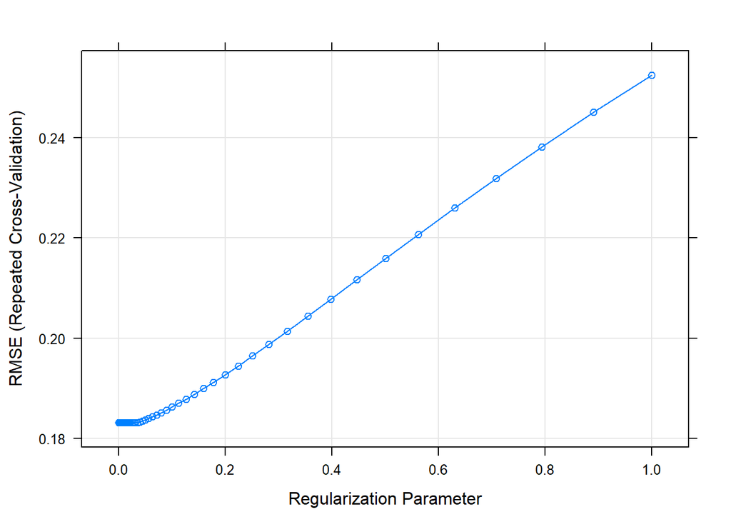

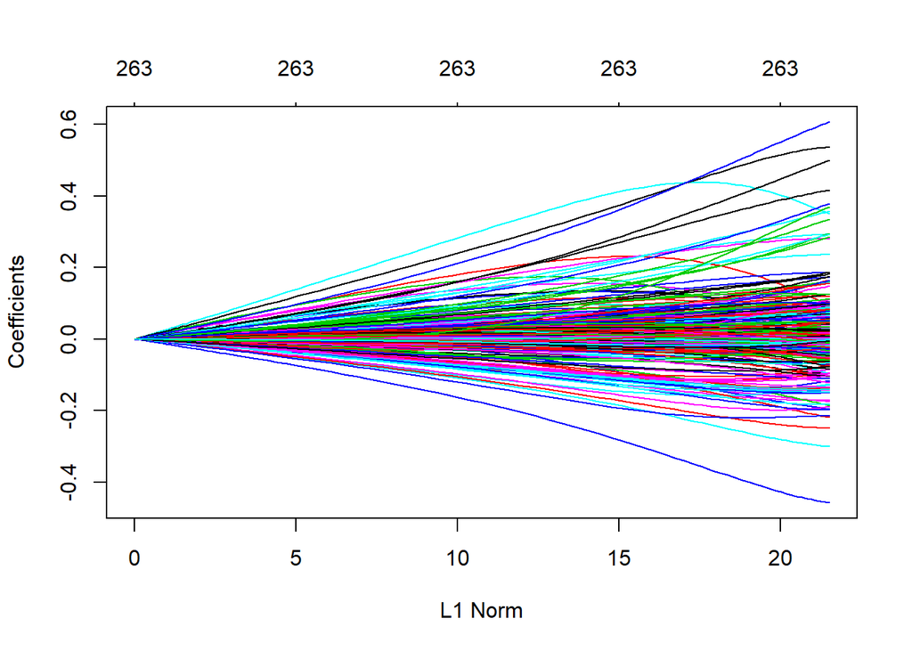

```
## [1] "The mean absolute error for Ridge regression is  69829.210867203 and mape is 0.129165694494557 and rmse is  128507.932046928"
```

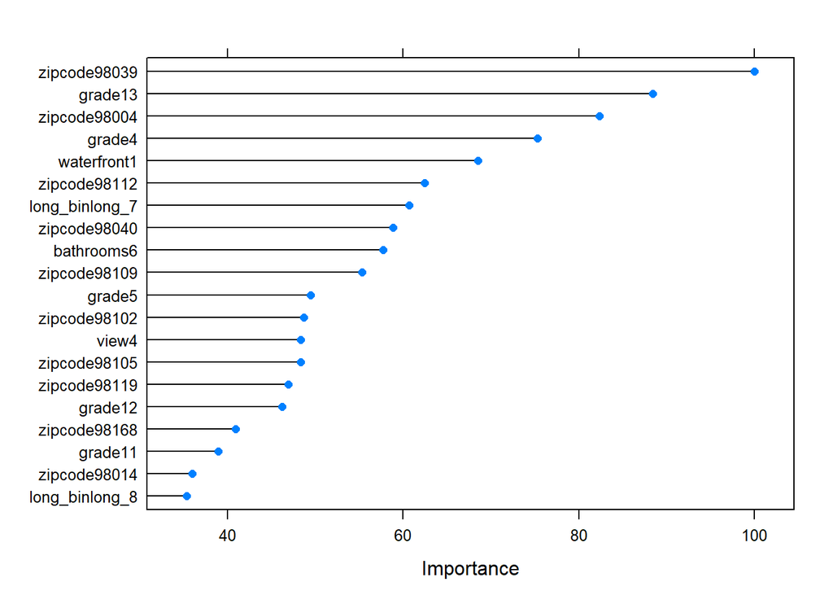

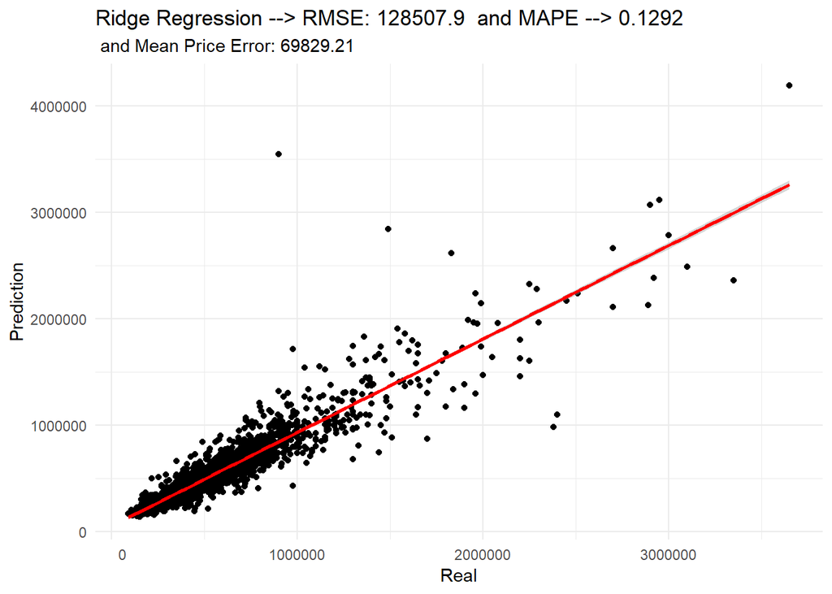

```
## [1] "Ridge R-Squared: 0.888242427753537"
```

##### 16.4 Lasso Regression

The only thing that changes between Lasso and Ridge is the alpha parameter. We will use the same sequence of lambda values used in ridge and apply lasso by changing alpha into 1. a value of 1 for alpha means that Lasso applies a higher penalty in the regularization more than in Ridge.

###### 16.4.1 Lasso Evaluation

```
##             Length Class      Mode
## a0             86  -none-     numeric
## beta        22790  dgCMatrix  S4
## df             86  -none-     numeric
## dim             2  -none-     numeric
## lambda         86  -none-     numeric
## dev.ratio      86  -none-     numeric
## nulldev         1  -none-     numeric
## npasses         1  -none-     numeric
## jerr            1  -none-     numeric
## offset          1  -none-     logical
## call            5  -none-     call
## nobs            1  -none-     numeric
## lambdaOpt       1  -none-     numeric
## xNames        265  -none-     character
## problemType     1  -none-     character
## tuneValue       2  data.frame list
## obsLevels       1  -none-     logical
## param           0  -none-     list
```

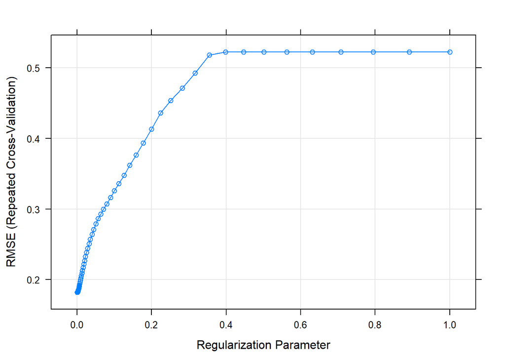

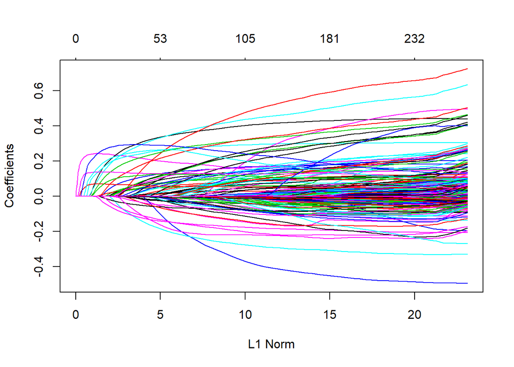

```
## [1] "The mean absolute error for Lasso regression is  69973.8585351119 and mape is 0.12921407958321 and rmse is  127252.380831655"
```

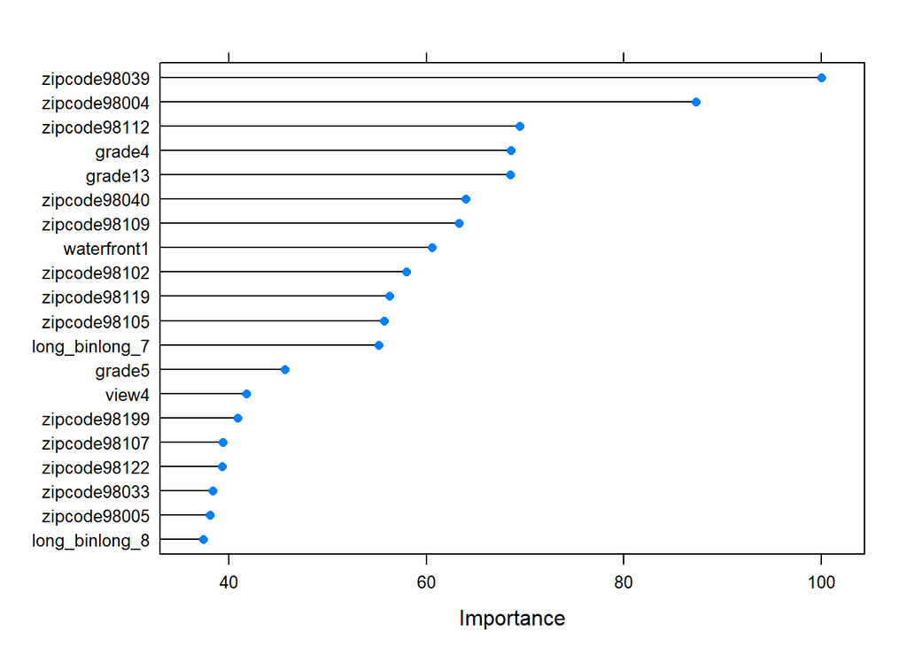

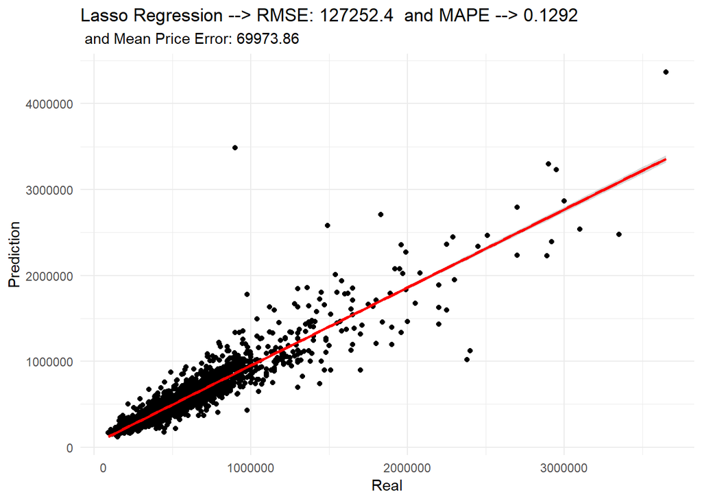

```
## [1] "Lasso R-Squared: 0.888583930523475"
```

##### 16.5 Defining Formulas For XGB & RF

Defining Formula to be used for the following models. We will definte two formulas and they will be used differently based on the model. Next we will try using XGBoost and Random Forest models and we will check for improvement.

##### 16.6 XGBoost

XGBoost is an implementation of gradient boosted decision trees designed for speed and performance. We will try using XGBoost with grid search using the parameters below. The initial grid search was performed and best parameters were selected for identifying the grid parameters. However, for convenience I commented out the grid search part for faster evaluation and knitting processes.

###### 16.6.1 XGBoost Evaluation

```
##               Length   Class              Mode
## handle               1 xgb.Booster.handle externalptr
## raw           44449249 -none-             raw
## niter                1 -none-             numeric
## call                 5 -none-             call
## params               8 -none-             list
## callbacks            1 -none-             list
## feature_names      265 -none-             character
## nfeatures            1 -none-             numeric
## xNames             265 -none-             character
## problemType          1 -none-             character
## tuneValue            7 data.frame         list
## obsLevels            1 -none-             logical
## param                0 -none-             list
```

```
## [1] "The mean absolute error for xgboost is  59157.6880124785 and mape is 0.114032283505186 and rmse is  102558.229721162"
```

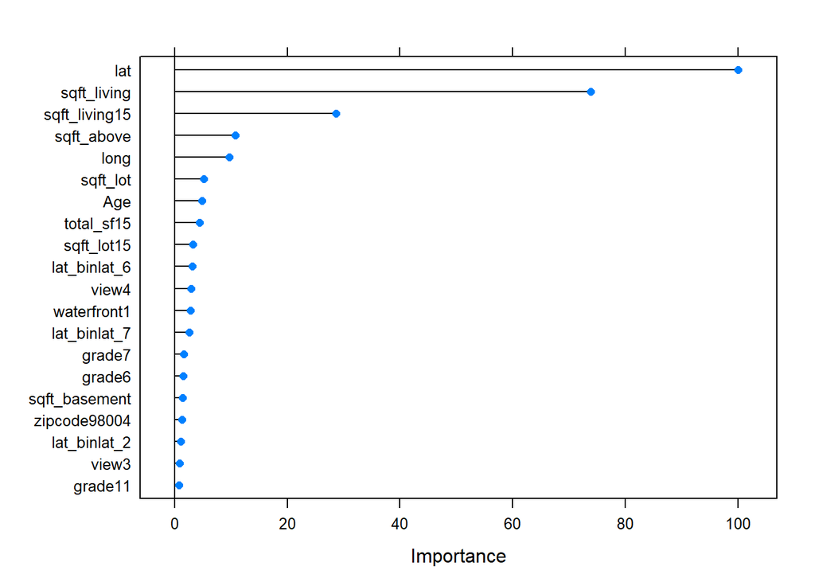

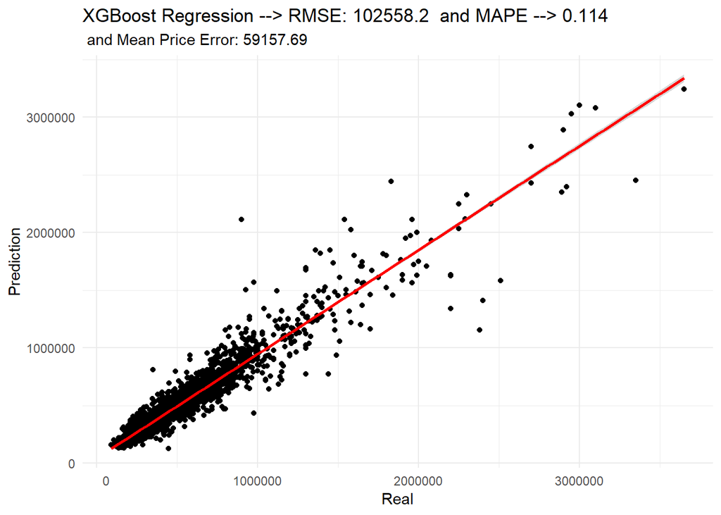

```
## [1] "XGB R-Squared: 0.908555603574829"
```

##### 16.7 Random Forest

Since RF does not accept factors more than 53 levels we will remove factors with more than 53 levels Therefore, we will use a separate dataset where we convert zipcode into a numeric variable and create a new formula with hand-picked variables to be used for the the model.

```
## 'data.frame':    14344 obs. of  24 variables:
##  $ price        : num  13.5 12.5 13.5 14 13.5 ...
##  $ bedrooms     : Factor w/ 9 levels "1","2","3","4",..: 3 2 4 4 4 2 3 3 4 1 ...
##  $ bathrooms    : Factor w/ 24 levels "0.5","0.75","1",..: 6 5 9 8 10 3 3 5 9 3 ...
##  $ sqft_living  : num  -0.304 -1.387 1.558 1.885 0.633 ...
##  $ sqft_lot     : num  -0.2392 -0.3746 0.6869 0.0939 -0.1931 ...
##  $ floors       : Factor w/ 6 levels "1","1.5","2",..: 1 3 3 1 3 1 1 1 3 1 ...
##  $ waterfront   : Factor w/ 2 levels "0","1": 1 1 1 1 1 1 1 1 1 1 ...
##  $ view         : Factor w/ 5 levels "0","1","2","3",..: 1 1 1 1 1 1 1 1 1 1 ...
##  $ condition    : Factor w/ 5 levels "1","2","3","4",..: 5 3 3 4 3 4 3 5 3 3 ...
##  $ grade        : Factor w/ 11 levels "3","4","5","6",..: 5 5 8 7 6 3 4 5 6 6 ...
##  $ sqft_above   : num  -1.096 -1.171 2.084 0.114 1.061 ...
##  $ sqft_basement: num  1.391 -0.662 -0.662 3.603 -0.662 ...
##  $ yr_built     : num  48 106 103 52 95 55 44 58 95 108 ...
##  $ zipcode      : num  70 50 9 66 29 1 19 27 23 57 ...
##  $ lat          : num  0.67 0.977 -1.574 1.029 0.899 ...
##  $ long         : num  -1.372 -0.639 1.347 -1.165 0.365 ...
##  $ sqft_living15: num  -0.49 -1.683 2.014 0.924 1.012 ...
##  $ sqft_lot15   : num  -0.2639 -0.4419 1.0798 -0.0625 -0.197 ...
##  $ total_sf15   : num  -0.2757 -0.4846 1.128 -0.0375 -0.1689 ...
##  $ has_basement : Factor w/ 2 levels "0","1": 2 1 1 2 1 1 1 1 1 2 ...
##  $ NewHouse     : Factor w/ 2 levels "0","1": 1 1 1 1 1 1 1 1 1 1 ...
##  $ Age          : num  0.938 -1.111 -0.972 0.764 -0.729 ...
##  $ long_bin     : Factor w/ 8 levels "long_1","long_2",..: 1 2 4 1 3 2 2 3 2 1 ...
##  $ lat_bin      : Factor w/ 8 levels "lat_1","lat_2",..: 7 7 3 7 7 2 3 3 8 5 ...
```

```
##
## Call:
##  randomForest(formula = rffomula, data = rftraining, keep.forest = TRUE,      keep.inbag = TRUE)
##                Type of random forest: regression
##                      Number of trees: 500
## No. of variables tried at each split: 6
##
##           Mean of squared residuals: 0.03217619
##                     % Var explained: 88.23
```

|  | IncNodePurity |
| --- | --- |
| bedrooms | 31.32 |
| bathrooms | 136.68 |
| sqft_living | 758.73 |
| sqft_lot | 70.99 |
| sqft_above | 217.37 |
| floors | 19.80 |
| waterfront | 15.24 |
| view | 64.24 |
| condition | 23.65 |
| grade | 648.96 |

[output cut: 9 more lines]

###### 16.7.1 Random Forest Evaluation

```
##                 Length  Class  Mode
## call                  5 -none- call
## type                  1 -none- character
## predicted         14344 -none- numeric
## mse                 500 -none- numeric
## rsq                 500 -none- numeric
## oob.times         14344 -none- numeric
## importance           19 -none- numeric
## importanceSD          0 -none- NULL
## localImportance       0 -none- NULL
## proximity             0 -none- NULL
## ntree                 1 -none- numeric
## mtry                  1 -none- numeric
## forest               11 -none- list
## coefs                 0 -none- NULL
## y                 14344 -none- numeric
## test                  0 -none- NULL
## inbag           7172000 -none- numeric
## terms                 3 terms  call
```

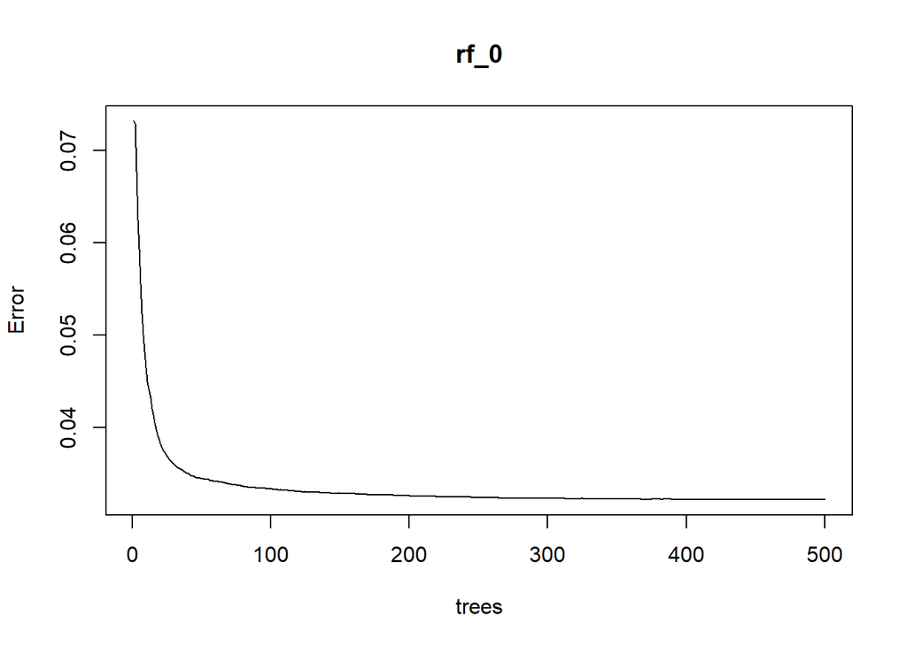

```
## [1] "The mean absolute error for Random Forest is  67430.1720650379 and mape is 0.121990029057895 and rmse is  124213.027202979"
```

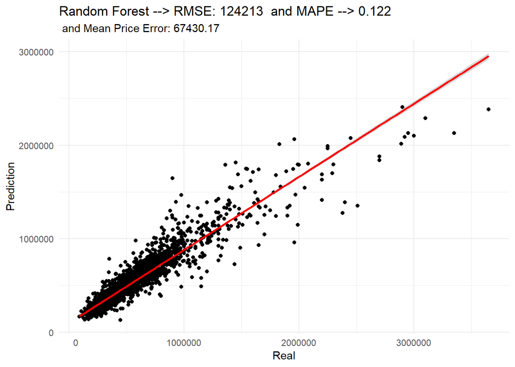

```
## [1] "Random Forest R-Squared: 0.893705307559679"
```

###### 16.7.2 Random Forest Tuning

After hyper-parameter optimization, model evaluation has not revealed any improvement in the original model. Therefore, XGBoost remains the best score of all implemented models.

##### 17. Model Comparison

Now we will compare all the implemented models based on all MAE, MAPE, RMSE, and R-squared values. The best model will be used to predict the test set.

```
## [1] "The mean absolute error for linear regression is  70573.3334715268 and mape is 0.130475009905006 and rmse is  127997.618902608"
```

```
## [1] "Linear Regression R-Squared: 0.884665123187455"
```

```
## [1] "The mean absolute error for ridge regression is  69829.210867203 and mape is 0.129165694494557 and rmse is  128507.932046928"
```

```
## [1] "Ridge R-Squared: 0.888242427753537"
```

```
## [1] "The mean absolute error for lasso regression is  69973.8585351119 and mape is 0.12921407958321 and rmse is  127252.380831655"
```

```
## [1] "Lasso R-Squared: 0.888583930523475"
```

```
## [1] "The mean absolute error for xgboost regression is  59157.6880124785 and mape is 0.114032283505186 and rmse is  102558.229721162"
```

```
## [1] "XGBoost R-Squared: 0.908555603574829"
```

```
## [1] "The mean absolute error for random forest regression is  67430.1720650379 and mape is 0.121990029057895 and rmse is  124213.027202979"
```

```
## [1] "Random Forest R-Squared: 0.893705307559679"
```

##### 18. Test Prediction

Now we will predict the test set using the best model. XGBoost gave the lowest mean absolute percentage error of 0.114.